# R Notebook for Forecasting

‘’’ #################### Simple Forecasting Methods ####################### 1. Average Method :- a.Forecast of the future value is mean of the historical data. b.Time Series and Cross Sectional data.

2. Naive Method :-
   1. Forecast of future value is the last value in time series.
   2. Time series.
3. Seasonal Naive Method :-
   1. Highly seasonal data.
   2. Forecast set to last observed value from the same season last year.
   3. Time Series.
4. Drift Method :-
   1. Variation of the Naive method.
   2. Forecast set to increase/decrease over time.
   3. Change is the average change observed in the historical data.

Loading the package for forcasting

We are going to use the Australian Beer data from fpp package. The data is available from 1956 to 2008 for each quarter.

```r
head(ausbeer)
```

```
     Qtr1 Qtr2 Qtr3 Qtr4
1956  284  213  227  308
1957  262  228
```

```r
tail(ausbeer)
```

```
     Qtr1 Qtr2 Qtr3 Qtr4
2007       383  394  473
2008  420  390  410
```

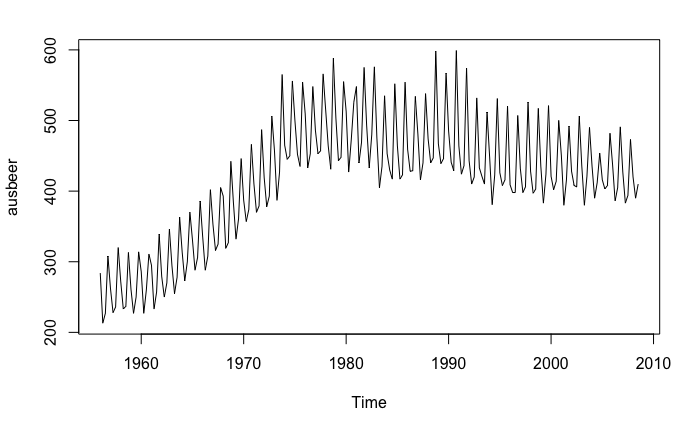

```r
# We will consider the data from 1992 to 2005
beer2 = window(ausbeer, start = 1992, end = 2006 - .1)
head(beer2)
```

```
     Qtr1 Qtr2 Qtr3 Qtr4
1992  443  410  420  532
1993  433  421
```

```r
tail(beer2)
```

```
     Qtr1 Qtr2 Qtr3 Qtr4
2004            412  454
2005  416  403  408  482
```

```r
beer3 = window(ausbeer, start = 2006)
```

```r
# Forecasting using the Average Method
beerfit_avg = meanf(beer2, h = 11)
beerfit_avg
```

|  | Point Forecast | Lo 80 | Hi 80 | Lo 95 | Hi 95 |
| --- | --- | --- | --- | --- | --- |
| 2006 Q1 | 436.9107 | 378.5756 | 495.2459 | 346.7841 | 527.0373 |
| 2006 Q2 | 436.9107 | 378.5756 | 495.2459 | 346.7841 | 527.0373 |
| 2006 Q3 | 436.9107 | 378.5756 | 495.2459 | 346.7841 | 527.0373 |
| 2006 Q4 | 436.9107 | 378.5756 | 495.2459 | 346.7841 | 527.0373 |
| 2007 Q1 | 436.9107 | 378.5756 | 495.2459 | 346.7841 | 527.0373 |
| 2007 Q2 | 436.9107 | 378.5756 | 495.2459 | 346.7841 | 527.0373 |
| 2007 Q3 | 436.9107 | 378.5756 | 495.2459 | 346.7841 | 527.0373 |
| 2007 Q4 | 436.9107 | 378.5756 | 495.2459 | 346.7841 | 527.0373 |
| 2008 Q1 | 436.9107 | 378.5756 | 495.2459 | 346.7841 | 527.0373 |
| 2008 Q2 | 436.9107 | 378.5756 | 495.2459 | 346.7841 | 527.0373 |

[output cut: 1 more lines]

```r
# In this case we are just taking the average of all the available values and using that as our forecast for future values.
```

```r
# Accuracy of the Method
accuracy(beerfit_avg,beer3)
```

```
                        ME     RMSE      MAE        MPE     MAPE     MASE        ACF1
Training set  8.121418e-15 44.17630 35.91135 -0.9510944 7.995509 2.444228 -0.12566970
Test set     -1.718344e+01 38.01454 33.77760 -4.7345524 8.169955 2.298999 -0.08286364
             Theil's U
Training set        NA
Test set     0.7901651
```

```r
print(paste("Root mean squared error is ",accuracy(beerfit_avg,beer3)[3]))
```

```
[1] "Root mean squared error is  44.1763013332918"
```

```r
# Forecasting using the Naive Method
beerfit_naive = rwf(beer2, h = 11)
beerfit_naive
```

|  | Point Forecast | Lo 80 | Hi 80 | Lo 95 | Hi 95 |
| --- | --- | --- | --- | --- | --- |
| 2006 Q1 | 482 | 396.6460 | 567.3540 | 351.46228 | 612.5377 |
| 2006 Q2 | 482 | 361.2912 | 602.7088 | 297.39179 | 666.6082 |
| 2006 Q3 | 482 | 334.1625 | 629.8375 | 255.90204 | 708.0980 |
| 2006 Q4 | 482 | 311.2919 | 652.7081 | 220.92456 | 743.0754 |
| 2007 Q1 | 482 | 291.1426 | 672.8574 | 190.10878 | 773.8912 |
| 2007 Q2 | 482 | 272.9262 | 691.0738 | 162.24919 | 801.7508 |
| 2007 Q3 | 482 | 256.1745 | 707.8255 | 136.62966 | 827.3703 |
| 2007 Q4 | 482 | 240.5824 | 723.4176 | 112.78357 | 851.2164 |
| 2008 Q1 | 482 | 225.9379 | 738.0621 | 90.38684 | 873.6132 |
| 2008 Q2 | 482 | 212.0869 | 751.9131 | 69.20348 | 894.7965 |

[output cut: 1 more lines]

```r
# Accuracy of the Method
accuracy(beerfit_naive,beer3)
```

```
                      ME     RMSE      MAE         MPE     MAPE     MASE        ACF1
Training set   0.7090909 66.60207 55.43636  -0.8987351 12.26632 3.773156 -0.25475212
Test set     -62.2727273 70.90647 63.90909 -15.5431822 15.87645 4.349833 -0.08286364
             Theil's U
Training set        NA
Test set      1.428524
```

```r
print(paste("Root mean squared error is ",accuracy(beerfit_naive,beer3)[3]))
```

```
[1] "Root mean squared error is  66.6020747697587"
```

```r
# Forecasting using the seasonal naive method
beerfit_snaive = snaive(beer2 , h = 11)
beerfit_snaive
```

|  | Point Forecast | Lo 80 | Hi 80 | Lo 95 | Hi 95 |
| --- | --- | --- | --- | --- | --- |
| 2006 Q1 | 416 | 393.9021 | 438.0979 | 382.2042 | 449.7958 |
| 2006 Q2 | 403 | 380.9021 | 425.0979 | 369.2042 | 436.7958 |
| 2006 Q3 | 408 | 385.9021 | 430.0979 | 374.2042 | 441.7958 |
| 2006 Q4 | 482 | 459.9021 | 504.0979 | 448.2042 | 515.7958 |
| 2007 Q1 | 416 | 384.7489 | 447.2511 | 368.2055 | 463.7945 |
| 2007 Q2 | 403 | 371.7489 | 434.2511 | 355.2055 | 450.7945 |
| 2007 Q3 | 408 | 376.7489 | 439.2511 | 360.2055 | 455.7945 |
| 2007 Q4 | 482 | 450.7489 | 513.2511 | 434.2055 | 529.7945 |
| 2008 Q1 | 416 | 377.7253 | 454.2747 | 357.4640 | 474.5360 |
| 2008 Q2 | 403 | 364.7253 | 441.2747 | 344.4640 | 461.5360 |

[output cut: 1 more lines]

```r
# Accuracy of the Method
accuracy(beerfit_snaive,beer3)
```

```
                    ME     RMSE      MAE        MPE     MAPE      MASE       ACF1
Training set -1.846154 17.24261 14.69231 -0.4803931 3.401224 1.0000000 -0.3408329
Test set     -2.545455 12.96849 11.27273 -0.7530978 2.729847 0.7672537 -0.1786912
             Theil's U
Training set        NA
Test set       0.22573
```

```r
print(paste("Root mean squared error is ",accuracy(beerfit_snaive,beer3)[3]))
```

```
[1] "Root mean squared error is  17.2426126879836"
```

Clearly Seasonal naive method has least root mean squared error.

Comaprison of the 3 methods graphically above

```r
plot(beerfit_avg,
     main = 'Forecast for quarterly beer production')
lines(beerfit_naive$mean, col = 2)
```

```r
lines(beerfit_snaive$mean, col = 3)
lines(ausbeer)
```

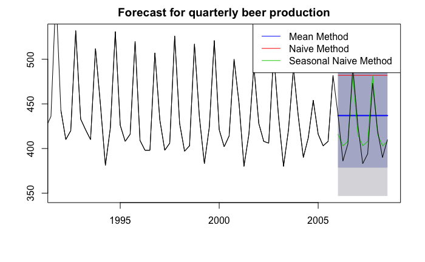

```r
legend("topright", lty = 1, col = c(4,2,3),
       legend = c("Mean Method", "Naive Method", "Seasonal Naive Method"))
```

The Seasonal Naive Method is the closest to the actual values which was expected as this is a seasonal data.

Now we are going to use a non seasonal data and see the performance of these models.

The data is Dow Jones Data

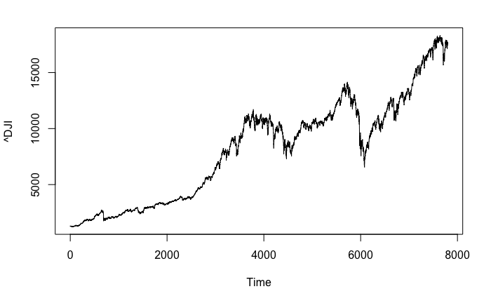

```r
# isntalling package for qrmdata
library(qrmdata)
dj = ts(DJ)
dj2 = window(dj, end = 250)
plot(dj)
```

```r
plot(dj2, main = "Dow Jones data daily",
     ylab = "", xlab = "Day", xlim = c(2,290), ylim = c(1240,1800))
lines(meanf(dj2, h = 42)$mean,col = 4)
```

```r
lines(rwf(dj2, h = 42)$mean, col = 2)
lines(rwf(dj2,drift = TRUE, h = 42)$mean, col = 3)
```

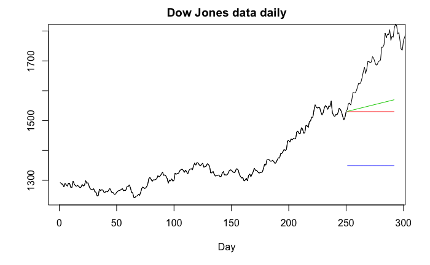

```r
lines(dj)
```

```r
# drift method calculates the average change over time and that is our slope for forecasting.
```

Time Series Regression We are going to use US Consumption data for this excerscise

```r
head(usconsumption)
```

```
        consumption    income
1970 Q1   0.6122769  0.496540
1970 Q2   0.4549298  1.736460
1970 Q3   0.8746730  1.344881
1970 Q4  -0.2725144 -0.328146
1971 Q1   1.8921870  1.965432
1971 Q2   0.9133782  1.490757
```

```r
ts.reg.fit = tslm(consumption ~ income ,data = usconsumption)
ts.reg.fit$coefficients
```

```
(Intercept)      income
  0.5206165   0.3186605
```

```r
# This means that consumptions = 0.5206165 + 0.3186605 * income
```

```r
summary(ts.reg.fit)
```

```
Call:
tslm(formula = consumption ~ income, data = usconsumption)

Residuals:
    Min      1Q  Median      3Q     Max
-2.3681 -0.3237  0.0266  0.3436  1.5581

Coefficients:
            Estimate Std. Error t value Pr(>|t|)
(Intercept)  0.52062    0.06231   8.356 2.79e-14 ***
income       0.31866    0.05226   6.098 7.61e-09 ***
---
Signif. codes:  0 ‘***’ 0.001 ‘**’ 0.01 ‘*’ 0.05 ‘.’ 0.1 ‘ ’ 1

Residual standard error: 0.6274 on 162 degrees of freedom
Multiple R-squared:  0.1867,    Adjusted R-squared:  0.1817
F-statistic: 37.18 on 1 and 162 DF,  p-value: 7.614e-09
```

We use time series regression for scenario based forecasting. For example, if we like to predict the consumption if income goes up 1 unit or decrease by 1 unit. This kind of forecasting is used mostly for insight rather than actually forecasting. We have to know the value of our predictor in advance.

|  | Point Forecast | Lo 80 | Hi 80 | Lo 95 | Hi 95 |
| --- | --- | --- | --- | --- | --- |
| 2011 Q1 | 0.2019561 | -0.61627881 | 1.020191 | -1.0537032 | 1.457615 |
| 2011 Q2 | 0.8392770 | 0.02922461 | 1.649329 | -0.4038255 | 2.082380 |

Time Series Decomposition Time series pattern :- 1. Trend - Long term increase/decrease. 2. Seasonlity - Seasonal patterns influenced by seasonal patterns. 3. Cyclic Pattern - Rise and fall not of fixed period. 4. Distributed Lags. 5. Trading Days.

Let’s look at a monthly housing data set.

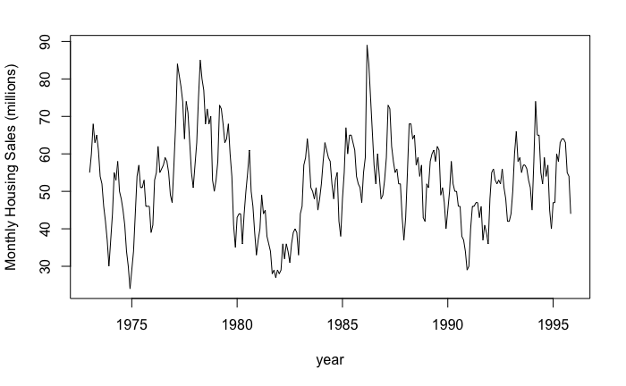

The plot above shows that within a year there is a increase and decrease in numbers and this is heppening in every which indicates that there is a seasonality present in the data.

Also, it can be seen that sales in 1975 is very low and then its is up for consecutive years till 1980 and drops again. This is an indication of a cyclic pattern in the data.

Let’s look at another dataset of US treasury.

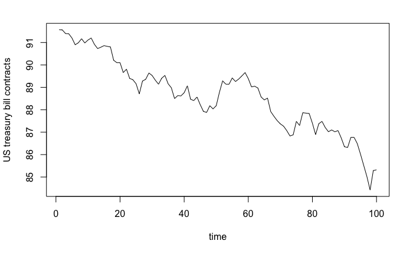

The above shows that there is downward trend over time but no clear indication of seasonality or cyclic variation.

Now we see Australian Monthly electricity production data

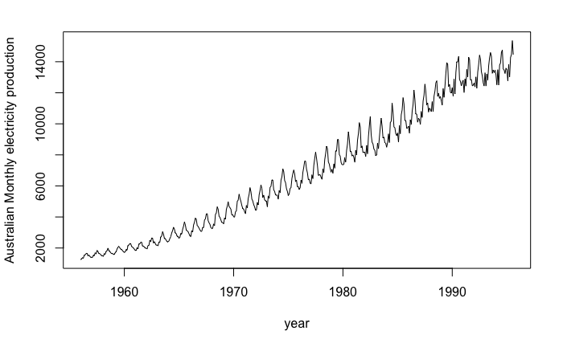

This plot shows that there is a upward trend present in the data. Also, seasonality can be seen in each year. But no cylclic pattern is visible.

Now we will try to decompose a time series.

We can write a time series model like :- Additve Model :- Y = S + T + E Multiplicative Model :- Y = S * T * E Multiplicative model can be made additive by taking log on both sides.

Forecasting with decomposition :-

Now we will decompose a time series into 2 components 1. Seasonal Component. 2. Seasonally adjusted component.

Then we will fit each component seperately.

We are considering the dataset Electrical equipment Production

```r
data("elecequip")
head(elecequip)
```

```
       Jan   Feb   Mar   Apr   May   Jun
1996 79.43 75.86 86.40 72.67 74.93 83.88
```

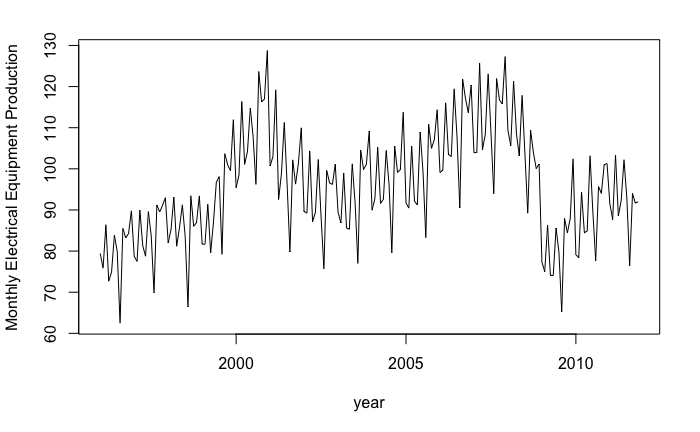

```r
# This dataset is available on a monthly scale.
plot(elecequip, xlab = "year", ylab = "Monthly Electrical Equipment Production")
```

```r
fit = stl(elecequip, t.window = 15, s.window = "periodic", robust = TRUE)
# t.window is the time period to be considered for trend.
# s.window is for seasonality and periodic means that seasonality is present all over the time series.
fit
```

```
 Call:
 stl(x = elecequip, s.window = "periodic", t.window = 15, robust = TRUE)

Components
           seasonal     trend   remainder
Jan 1996  -5.051366  80.83499  3.64637176
Feb 1996  -5.720456  80.58638  0.99407967
Mar 1996   8.107375  80.33776 -2.04513349
Apr 1996  -6.069824  80.13204 -1.39221608
May 1996  -4.743848  79.92632 -0.25247309
Jun 1996   7.862700  79.74923 -3.73192610
Jul 1996  -1.696899  79.57213  2.00476763
Aug 1996 -16.716058  79.73419 -0.54813027
Sep 1996   7.407193  79.89625 -1.80343887
Oct 1996   3.080603  80.36832 -0.25892729
Nov 1996   3.897675  80.84040 -0.44807728
Dec 1996   9.642903  81.37757 -1.23047079
Jan 1997  -5.051366  81.91473  1.85663278
Feb 1997  -5.720456  82.46011  0.75034373
Mar 1997   8.107375  83.00549 -1.17286639
Apr 1997  -6.069824  83.48315  3.93667468
May 1997  -4.743848  83.96081 -0.45695868
Jun 1997   7.862700  84.31610 -2.58879630
Jul 1997  -1.696899  84.67139  0.77551281
Aug 1997 -16.716058  84.99257  1.59348920
Sep 1997   7.407193  85.31375 -1.54094512
Oct 1997   3.080603  85.63623  0.80316763
Nov 1997   3.897675  85.95871  1.26361882
Dec 1997   9.642903  86.15994 -2.83283932
Jan 1998  -5.051366  86.36117  0.66019962
Feb 1998  -5.720456  86.30001  4.68044906
Mar 1998   8.107375  86.23885 -1.25622257
Apr 1998  -6.069824  86.03955  1.22027767
May 1998  -4.743848  85.84024  4.64360349
Jun 1998   7.862700  85.49061 -2.11330820
Jul 1998  -1.696899  85.14097  0.11592683
Aug 1998 -16.716058  84.90058 -1.73452531
Sep 1998   7.407193  84.66020  1.38261183
Oct 1998   3.080603  84.70576 -1.75636435
Nov 1998   3.897675  84.75133 -1.73900210
```

[output cut: 141 more lines]

```
Sep 2010   7.407193  92.30827 -4.03545902
Oct 2010   3.080603  92.70872 -1.75932791
Nov 2010   3.897675  93.10918  3.98314164
Dec 2010   9.642903  93.49820 -1.88110173
Jan 2011  -5.051366  93.88721  2.63415199
Feb 2011  -5.720456  94.19432 -0.81386510
Mar 2011   8.107375  94.50143  0.72119674
Apr 2011  -6.069824  94.09515  0.53467828
May 2011  -4.743848  93.68886  3.37498540
Jun 2011   7.862700  92.92493  1.42237340
Jul 2011  -1.696899  92.16099  2.33590813
Aug 2011 -16.716058  91.36784  1.78821793
Sep 2011   7.407193  90.57469 -3.98188297
Oct 2011   3.080603  89.69429 -1.10489802
Nov 2011   3.897675  88.81390 -0.73157464
```

Now lets remove seasonality from the data and fit the adjusted numbers using naive method.

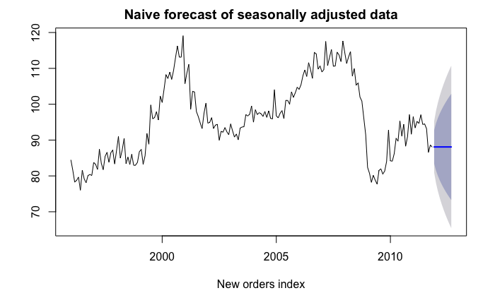

|  | Point Forecast | Lo 80 | Hi 80 | Lo 95 | Hi 95 |
| --- | --- | --- | --- | --- | --- |
| Dec 2011 | 97.72523 | 93.03982 | 102.41064 | 90.55951 | 104.89094 |
| Jan 2012 | 83.03096 | 76.40479 | 89.65713 | 72.89711 | 93.16481 |
| Feb 2012 | 82.36187 | 74.24650 | 90.47723 | 69.95049 | 94.77325 |
| Mar 2012 | 96.18970 | 86.81888 | 105.56052 | 81.85827 | 110.52113 |
| Apr 2012 | 82.01250 | 71.53561 | 92.48939 | 65.98948 | 98.03553 |
| May 2012 | 83.33848 | 71.86162 | 94.81534 | 65.78613 | 100.89082 |
| Jun 2012 | 95.94502 | 83.54860 | 108.34145 | 76.98633 | 114.90372 |
| Jul 2012 | 86.38543 | 73.13309 | 99.63776 | 66.11773 | 106.65313 |
| Aug 2012 | 71.36627 | 57.31004 | 85.42249 | 49.86912 | 92.86341 |
| Sep 2012 | 95.48952 | 80.67295 | 110.30608 | 72.82954 | 118.14949 |

[output cut: 14 more lines]

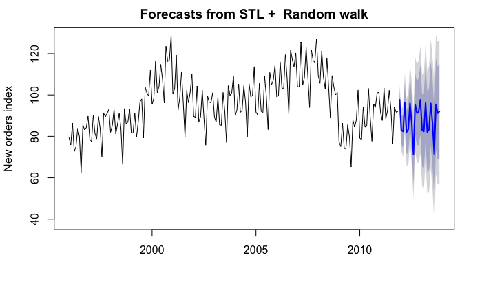

In the above plot we can see that it has adjusted the naive method with seasonality.

Moving Average:- The forecast for current time is the average of last k time events.

Let’s consider the Electricity Sales data :-

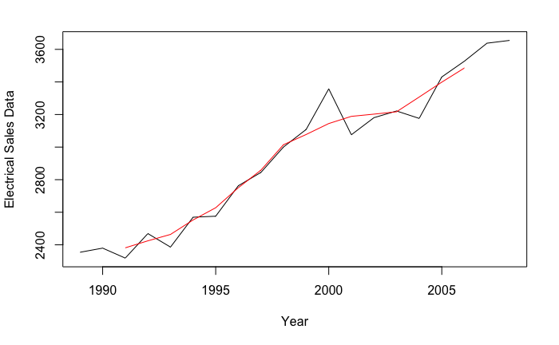

```r
data("elecsales")
plot(elecsales, ylab = "Electrical Sales Data", xlab = "Year")
# Now the 5 year moving average data
lines(ma(elecsales, order = 5), col = "red")
```

Simple Exponential Smoothing :- This method assumes that there is no trend or seasonality present in the data. This method gives more weight to the recent observations and weight decrease over time in the past.

Let’s fit exponential smoothing on oil Production data :-

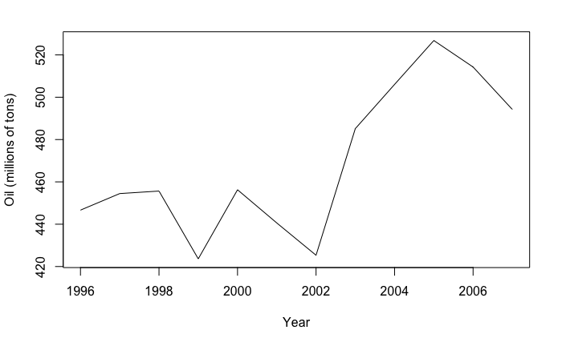

```r
data("oil")
oildata = window (oil, start = 1996, end = 2007)
plot(oildata, ylab = "Oil (millions of tons)", xlab = "Year")
```

This data do not have any seasonal or cyclic varaition. Also, not any strong indication of a trend.

```r
fit1 = ses(oildata, alpha = 0.2 , initial = "simple", h = 3)
fit2 = ses(oildata, alpha = 0.6 , initial = "simple", h = 3)
fit3 = ses(oildata , h = 3)
plot(fit1, ylab = "Oil (Millions of tons)", xlab = "Year", type = "o", fcol = "white")
lines(fitted(fit1), col = "blue", type = "o")
```

```r
lines(fitted(fit2), col = "red", type = "o")
lines(fitted(fit3), col = "green", type = "o")
```

```r
lines(fit1$mean, col = "blue", type = "o")
lines(fit2$mean, col = "red", type = "o")
```

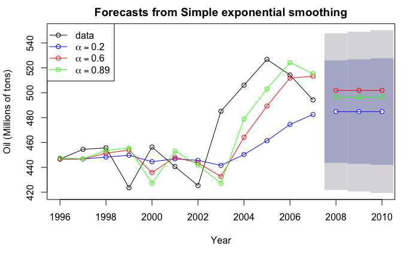

```r
lines(fit3$mean, col = "green", type = "o")
legend("topleft", lty =1, col = c(1, "blue", "red", "green"),
      c("data", expression(alpha == 0.2), expression(alpha == 0.6),
        expression(alpha == 0.89)), pch = 1)
```

It can be seen that increasing the alpha just increasing the flexibility of the model.

ARIMA Modeling :- This modeling aims to explain the suto correlation in the data.

Two components of ARIMA are :- 1. Auto regressive :- This means that we are regressing a variable on its own past value. 2. Moving Average.

Before start on ARIMA, let’s understand some more terms in our mind. Stationary = Time series that are independent of time are called stationary time series.

Time series with trend and seasonality factors are not stationary.

Time series with cyclic variation are stationary.

Stationary Series are not predictable.

Some ways of making a time series stationary:-

Differencing :- Calculating the difference between consecutive observation points. Differencing removes trend and seasonality.

Transformation the variable. For eg. log transformation.

Auto Regressive Model

Auto Regressive Model - Forecast variable of interest using linear combination of the past values of the variable of interest.

AR(p) = A + Y(t-1) + Y(t-2) + …… + Y(t-p) + E where p is the order of auto regressive.

Special Cases of AR(1) Model. 1. if b = 0 then y = a (This is called white noise as the variation in forecasted values is because of the random error term). 2. if b = 1 and a = 0 then y = y(t-1) (This is called random walk as the forecasted value is just based on the last value). 3. if b = 1 and a!= 0 then y = a + y(t-1) (This is called random walk with drift).

Moving Average Model

These are regression like model using past forecast errors. We use the weighted average of the past forecast errors.

MA(p) = A + Et + E(t-1) + E(t-2) +…… + E(t-p). p is the order of moving average.

Non Seasonal ARIMA models

Differencing with Auto Regressive + Moving Average Model.

Yt = A + Y’(t-1) + Y’(t-2) +…..+ Y’(t-p) + Et + E(t-1) + E(t-2) +…..+ E(t-q)

ARIMA(p,d,q) p = order of the autoregressive part. q = order of the moving average. d = degree of the differencing involved.

auto.arima function can be used to determine these parameters

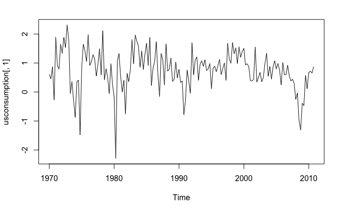

```r
plot(usconsumption[,1])
```

```r
# Now lets use the auto.arima function
fit = auto.arima(usconsumption[,1], seasonal = FALSE)
fit
```

```
Series: usconsumption[, 1]
ARIMA(0,0,3) with non-zero mean

Coefficients:
         ma1     ma2     ma3    mean
      0.2542  0.2260  0.2695  0.7562
s.e.  0.0767  0.0779  0.0692  0.0844

sigma^2 estimated as 0.3953:  log likelihood=-154.73
AIC=319.46   AICc=319.84   BIC=334.96
```

This means that a MA(3) model is best for this dataset.

```r
fit = Arima(usconsumption[,1], order = c(0,0,3))
```

The paramters can also be decided using the ACF and PACF plots. ACF = Auto Correlation Factor. This represents the correlation between points seperated by time period. ACF can be used to decide the q of the ARIMA model. PACF = Partial auto correlation Factor. This measure the partial correlation. Y(t) can be correlated to Y(t-2) because both are correlated to Y(t-1).

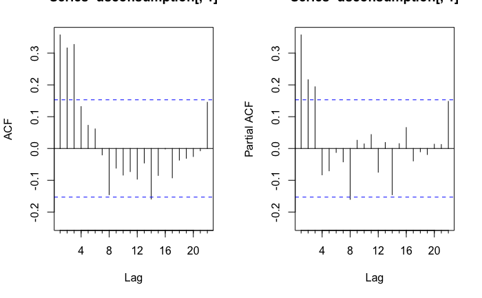

```r
par(mfrow = c(1,2))
Acf(usconsumption[,1])
Pacf(usconsumption[,1])
```

The PACF plot is exponentially decreasing but there is a spike at lag 3 in ACF plot. So the best model is ARIMA(0,0,3).

Now we will fit a ARIMA model on Electrical Equipment data

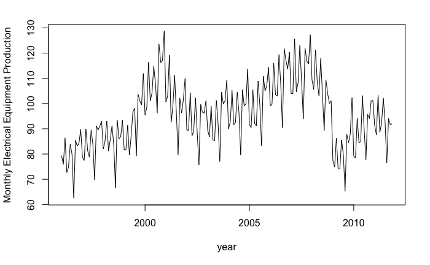

```r
plot(elecequip, xlab = "year", ylab = "Monthly Electrical Equipment Production")
```

```r
eeadj = seasadj(stl(elecequip, s.window = "periodic"))
```

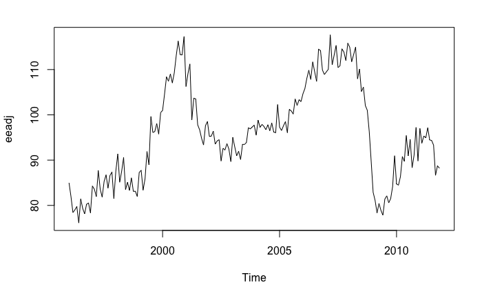

```r
plot(eeadj)
```

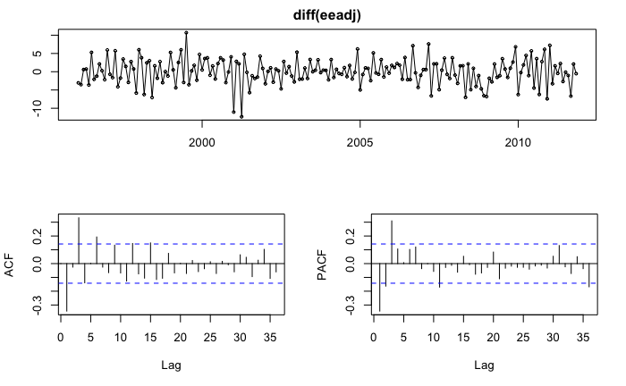

```r
tsdisplay(diff(eeadj))
```

```r
auto.arima(eeadj)
```

```
Series: eeadj
ARIMA(3,1,1)

Coefficients:
         ar1     ar2     ar3      ma1
      0.0519  0.1191  0.3730  -0.4542
s.e.  0.1840  0.0888  0.0679   0.1993

sigma^2 estimated as 9.737:  log likelihood=-484.08
AIC=978.17   AICc=978.49   BIC=994.4
```

```r
fit = Arima(eeadj, order = c(3,1,1))
summary(fit)
```

```
Series: eeadj
ARIMA(3,1,1)

Coefficients:
         ar1     ar2     ar3      ma1
      0.0519  0.1191  0.3730  -0.4542
s.e.  0.1840  0.0888  0.0679   0.1993

sigma^2 estimated as 9.737:  log likelihood=-484.08
AIC=978.17   AICc=978.49   BIC=994.4

Training set error measures:
                       ME     RMSE      MAE         MPE     MAPE      MASE        ACF1
Training set -0.001227744 3.079373 2.389267 -0.04290849 2.517748 0.2913919 0.008928479
```

```r
fit = Arima(eeadj, order = c(3,1,0))
summary(fit)
```

```
Series: eeadj
ARIMA(3,1,0)

Coefficients:
          ar1      ar2     ar3
      -0.3488  -0.0386  0.3139
s.e.   0.0690   0.0736  0.0694

sigma^2 estimated as 9.853:  log likelihood=-485.67
AIC=979.33   AICc=979.55   BIC=992.32

Training set error measures:
                     ME     RMSE      MAE         MPE     MAPE      MASE        ACF1
Training set 0.01170679 3.105828 2.430723 -0.04353974 2.560168 0.2964478 -0.03463506
```

```r
fit = Arima(eeadj, order = c(4,1,0))
summary(fit)
```

```
Series: eeadj
ARIMA(4,1,0)

Coefficients:
          ar1      ar2     ar3     ar4
      -0.3847  -0.0341  0.3551  0.1138
s.e.   0.0723   0.0731  0.0737  0.0728

sigma^2 estimated as 9.777:  log likelihood=-484.45
AIC=978.9   AICc=979.23   BIC=995.14

Training set error measures:
                      ME     RMSE      MAE         MPE     MAPE      MASE          ACF1
Training set 0.005571975 3.085604 2.401538 -0.04310566 2.528205 0.2928884 -0.0002297176
```

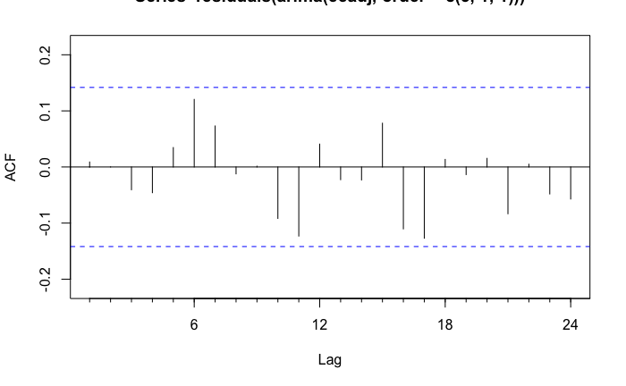

```r
Acf(residuals(arima(eeadj, order = c(3,1,1))))
```

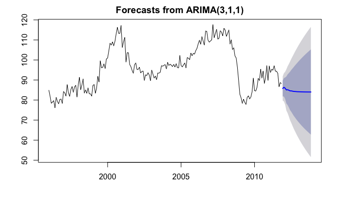

```r
plot(forecast(arima(eeadj, order = c(3,1,1))))
```

Seasonal ARIMA Models

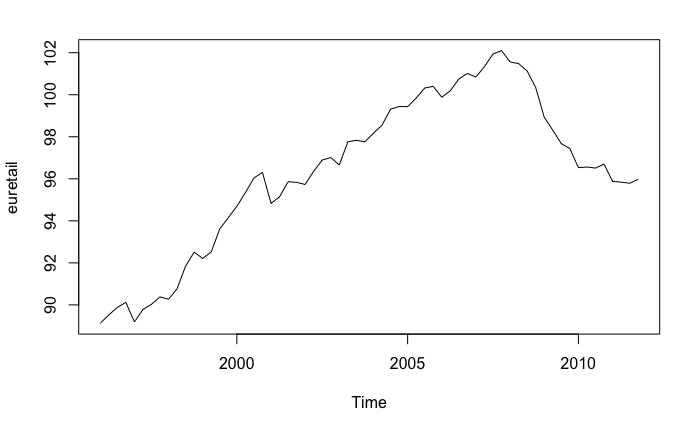

```r
data("euretail")
plot(euretail)
```

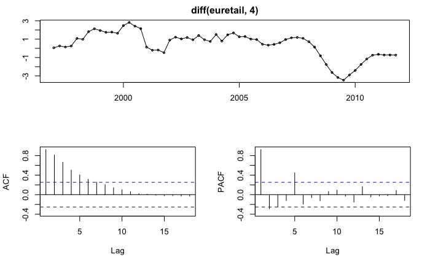

```r
tsdisplay(diff(euretail,4))
```

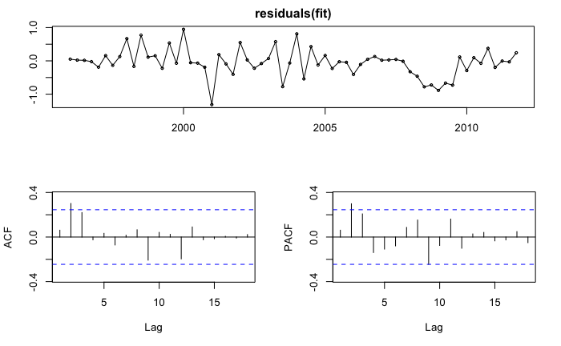

```r
fit = Arima(euretail, order = c(0,1,1), seasonal = c(0,1,1))
tsdisplay(residuals(fit))
```

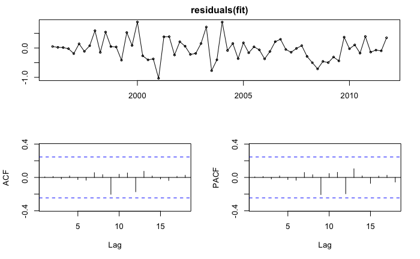

```r
fit = Arima(euretail, order = c(0,1,3), seasonal = c(0,1,1))
tsdisplay(residuals(fit))
```

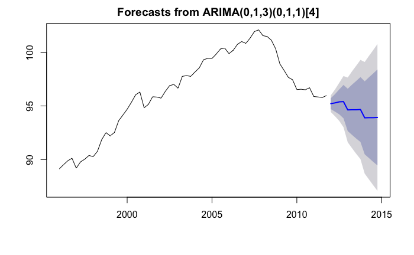

```r
plot(forecast(fit, h = 12))
```

```r
auto.arima(euretail)
```

```
Series: euretail
ARIMA(1,1,2)(0,1,1)[4]

Coefficients:
         ar1      ma1     ma2     sma1
      0.7345  -0.4655  0.2162  -0.8413
s.e.  0.2239   0.1995  0.2096   0.1869

sigma^2 estimated as 0.1592:  log likelihood=-29.69
AIC=69.37   AICc=70.51   BIC=79.76
```